# Assignment 1 - Summer 2025

Author

Dr. Seals

In this project, we will be analyzing the state-by-state spending on kids, as generously provided by the Urban Institute. Specifically, we will be investigating library spending that has been adjusted for inflation. To get started, see the starter code available on Canvas.

**1a. Find the summary statistics for library spending in all regions for the following years: 2000, 2005, 2010, and 2015.**

```r
all_regions %>% mean_median(y2000, y2005, y2010, y2015)
```

```
# A tibble: 4 × 3
  variable mean_sd             median_iqr
  <chr>    <chr>               <chr>
1 y2000    170365.3 (210403.4) 94284.0 (197973.0)
2 y2005    203254.1 (244136.0) 121970.0 (220287.5)
3 y2010    205501.7 (234078.5) 124954.0 (209843.5)
4 y2015    206475.8 (237210.8) 131088.0 (211980.5)
```

**1b. Find the summary statistics for library spending for the Northeast and Midwest regions for the following years: 2000, 2005, 2010, and 2015.**

```r
ne_mw_only %>% group_by(Region) %>% mean_median(y2000, y2005, y2010, y2015)
```

```
# A tibble: 8 × 4
  Region    variable mean_sd             median_iqr
  <chr>     <chr>    <chr>               <chr>
1 Midwest   y2000    204973.1 (184965.1) 153986.0 (237771.5)
2 Northeast y2000    225917.7 (308950.3) 144411.0 (240548.0)
3 Midwest   y2005    253297.6 (217860.2) 256921.0 (311636.0)
4 Northeast y2005    247108.9 (322143.8) 166699.0 (222950.0)
5 Midwest   y2010    237745.3 (203980.9) 223638.0 (288909.5)
6 Northeast y2010    240377.4 (271616.6) 168927.0 (239392.0)
7 Midwest   y2015    237205.5 (198779.3) 209956.0 (273822.5)
8 Northeast y2015    236386.0 (279866.3) 174435.0 (240292.0)
```

**2a. Suppose we are interested in comparing the 2010 spending between the Northeast and Midwest regions. Construct the appropriate QQ plot to check assumptions.**

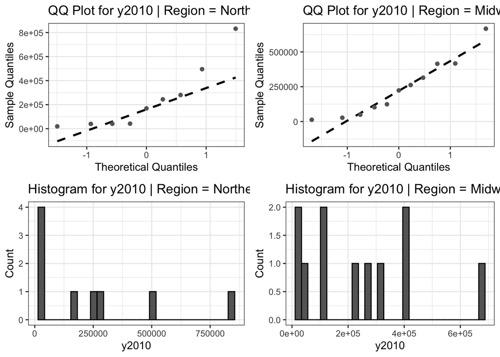

```r
ne_mw_only %>% independent_qq(continuous = y2010,
                              grouping = Region)
```

**2b. Suppose we are interested in comparing the 2010 spending between the Northeast and Midwest regions. If appropriate, examine the variance assumption. Do we violate the variance assumption? Remember to draw your final conclusion about the assumption (did we violate the assumption?). Note: If we do not care about the variance assumption here, leave this problem blank.**

```r
ne_mw_only %>% variances_HT(continuous = y2010,
                              grouping = Region)
```

```
Brown-Forsythe-Levene test for equality of variances:
Null: σ²_Northeast = σ²_Midwest
Alternative: At least one variance is different
Test statistic: F(1,18) = 0.179
p-value: p = 0.677
Conclusion: Fail to reject the null hypothesis (p = 0.677 ≥ α = 0.05)
```

- **Hypotheses:**
  - $H_0: \ \sigma^2_{\text{NE}} = \sigma_{\text{MW}}^2$
  - $H_1: \ \sigma^2_{\text{NE}} \ne \sigma_{\text{MW}}^2$
- **Test Statistic and *p*-Value**
  - $F_0 = 0.179$, $p = 0.677$
- **Rejection Region**
  - Reject $H_0$ if $p < \alpha$; $\alpha = 0.05$
- **Conclusion and interpretation**
  - Fail to reject $H_0$ ($p \text{ vs } \alpha \to 0.677 > 0.05$). There is not sufficient evidence to suggest that the variances are different. That is, we do not break the variance assumption of the two-sample *t*-test.

**3. Use the appropriate *t*-test to determine if there is a difference in library spending between the Northeast and Midwest regions in 2010. Test at the $\alpha=0.05$ level. Remember to typeset the results.**

```r
ne_mw_only %>% independent_mean_HT(continuous = y2010,
                                   grouping = Region)
```

```
Two-sample t-test for two independent means and equal variance:
Null: H₀: μ₁ − μ₂ = 0
Alternative: H₁: μ₁ − μ₂ ≠ 0
Test statistic: t(18) = -0.025
p-value: p = 0.981
Conclusion: Fail to reject the null hypothesis (p = 0.9805 ≥ α = 0.05)
```

- **Hypotheses**
  - $H_0:$ $\mu_{\text{NE}}-\mu_{\text{MW}} = 0$
  - $H_1:$ $\mu_{\text{NE}}-\mu_{\text{MW}} \ne 0$
- **Test Statistic and *p*-Value**
  - $t_0 = -0.025$, $p = 0.981$
- **Rejection Region**
  - Reject $H_0$ if $p < \alpha$; $\alpha=0.05$.
- **Conclusion/Interpretation**
  - Fail to reject $H_0$. There is not sufficient evidence to suggest that the spending in the northeast and midwest regions was different in 2010.

**4. Use the appropriate nonparametric test to determine if there is a difference in library spending between the Northeast and Midwest regions in 2010. Test at the $\alpha=0.05$ level. Remember to typeset the results.**

```r
ne_mw_only %>% independent_median_HT(continuous = y2010,
                                     grouping = Region)
```

```
Wilcoxon Rank Sum Test for two independent medians
Null: H₀: M₁ - M₂ = 0
Alternative: H₁: M₁ - M₂ ≠ 0
Test statistic: T = 53
p-value: p = 0.820
Conclusion: Fail to reject the null hypothesis (p = 0.8197 ≥ α = 0.05)
```

- **Hypotheses**
  - $H_0:$ $M_{\text{NE}}-M_{\text{MW}} = 0$
  - $H_1:$ $M_{\text{NE}}-M_{\text{MW}} \ne 0$
- **Test Statistic and *p*-Value**
  - $T_0 = 53$, $p = 0.820$
- **Rejection Region**
  - Reject $H_0$ if $p < \alpha$; $\alpha=0.05$.
- **Conclusion/Interpretation**
  - Fail to reject $H_0$. There is not sufficient evidence to suggest that the spending in the northeast and midwest regions was different in 2010.

**5. Based on your graph in Q2a, which test should be reported (the *t*-test or the Wilcoxon)? Explain why you’re choosing the test you’re choosing.**

- If normality assumption holds $\to$ *t*-test.
- If normality assumption does not hold $\to$ Wilcoxon.

**6a. Suppose we are interested in comparing the 2010 and 2015 spending for all states. Construct the appropriate QQ plot to check assumptions.**

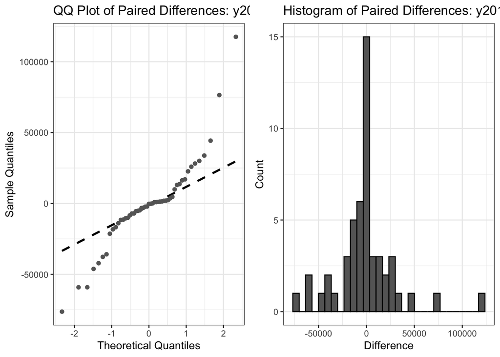

```r
all_regions %>% dependent_qq(col1 = y2010, col2 = y2015)
```

**6b. Suppose we are interested in comparing the 2010 and 2015 spending for all states. If appropriate, examine the variance assumption. Do we violate the variance assumption? Remember to draw your final conclusion about the assumption (did we violate the assumption?). Note: If we do not care about the variance assumption here, leave this problem blank.**

**7. Use the appropriate *t*-test to determine if there is a difference in library spending between 2010 and 2015 for all states. Test at the $\alpha=0.05$ level. Remember to typeset the results.**

```r
all_regions %>% dependent_mean_HT(col1 = y2010,
                                  col2 = y2015)
```

```
Paired t-test for the mean of differences:
Null: H₀: μ_d = 0
Alternative: H₁: μ_d ≠ 0
Test statistic: t(50) = -0.224
p-value: p = 0.823
Conclusion: Fail to reject the null hypothesis (p = 0.8235 ≥ α = 0.05)
```

- **Hypotheses**
  - $H_0:$ $\mu_{\text{2010}}-\mu_{\text{2015}} = 0$
  - $H_1:$ $\mu_{\text{2010}}-\mu_{\text{2015}} \ne 0$
- **Test Statistic and *p*-Value**
  - $t_0 = -0.224$; $p = 0.823$
- **Rejection Region**
  - Reject $H_0$ if $p < \alpha$; $\alpha=0.05$.
- **Conclusion/Interpretation**
  - Fail to reject $H_0$. There is not sufficient evidence to suggest that the spending changed between 2010 and 2015.

**8. Use the appropriate nonparametric test to determine if there is a difference in library spending between 2010 and 2015 for all states. Test at the $\alpha=0.05$ level. Remember to typeset the results.**

```r
all_regions %>% dependent_median_HT(col1 = y2010,
                                    col2 = y2015)
```

```
Wilcoxon Signed-Rank Test for the median of differences:
Null: H₀: M_d = 0
Alternative: H₁: M_d ≠ 0
Test statistic: T = 586
p-value: p = 0.473
Conclusion: Fail to reject the null hypothesis (p = 0.4733 ≥ α = 0.05)
```

**9. Based on your graph in Q6a, which test should be reported (the *t*-test or the Wilcoxon)? Explain why you’re choosing the test you’re choosing.**

- If normality assumption holds $\to$ *t*-test.
- If normality assumption does not hold $\to$ Wilcoxon.